# Week 3

## Case Study 1 : DNA Translation

### Introduction to DNA Translation

DNA information is carried by the dioxyribonucleic acid  
DNA is a discrete code physically present in almost every cell of an organism.  
We can think of DNA as a one dimensional string of characters with four characters to choose from. These characters are A, C, G, and T  
Adenine, Cytosine, Guanine, and Thymine.

Each unique three character sequence of nucleotides, sometimes called a nucleotide triplet, corresponds to one amino acid.  
The sequence of amino acids is unique for each type of protein and all proteins are built from the same set of just 20 amino acids

Protein molecules dominate the behavior of the cell serving as structural supports, chemical catalysts, molecular motors, and so on.

The so called central dogma of molecular biology describes the flow of genetic information in a biological system.

Instructions in the DNA are first transcribed into RNA and the RNA is then translated into proteins.

The input to our program is going to be a DNA sequence that consists of a four letter alphabet.  
We then read this sequence three letters at a time, translate each triplet to a single letter that stands for a specific amino acid, and proceed to the next set of three letters.

ATA -> I  
ATG -> M  
CAA -> Q  
TCT -> S  
TGG -> W

Task 1 : manually download DNA and protein sequence data  
Task 2 : Import the DNA data into Python  
Task 3 : Create an algorithm to translate the DNA  
Task 4 : Check if translation matches your download

https://www.ncbi.nlm.nih.gov/

Select the Category 'Nucleotide' and search for NM_207618.2 and click on 'FASTA' at the top  
copy the DNA (Ensure First letter 'G' and Last letter 'T' are selectecd) and save it as DNA.txt

Go back to the download page and click on 'CDS' and you should see a pop at the bottom  
SELECT translate and copy and paste it to a text file protein.txt in the same folder

```python
pwd
```

```
'D:\\Dev\\Python\\anaconda_pyscripts'
```

```python
import os
os.chdir('D:/Dev/Python/PythonForResearch/python_case_studies/translate')

inputfile = "dna.txt"
f = open(inputfile, "r")
seq = f.read()                     # read the entire file
seq
```

```
'GGTCAGAAAAAGCCCTCTCCATGTCTACTCACGATACATCCCTGAAAACCACTGAGGAAGTGGCTTTTCA\nGATCATCTTGCTTTGCCAGTTTGGGGTTGGGACTTTTGCCAATGTATTTCTCTTTGTCTATAATTTCTCT\nCCAATCTCGACTGGTTCTAAACAGAGGCCCAGACAAGTGATTTTAAGACACATGGCTGTGGCCAATGCCT\nTAACTCTCTTCCTCACTATATTTCCAAACAACATGATGACTTTTGCTCCAATTATTCCTCAAACTGACCT\nCAAATGTAAAT…
```

```python
seq = seq.replace("\n", "")   # replace line ending
seq
```

```
'GGTCAGAAAAAGCCCTCTCCATGTCTACTCACGATACATCCCTGAAAACCACTGAGGAAG…'
```

```python
seq = seq.replace("\r", "")  # replace \r if it is there
```

Download table.py

remove the indent

```python
table = {
'ATA':'I', 'ATC':'I', 'ATT':'I', 'ATG':'M',
'ACA':'T', 'ACC':'T', 'ACG':'T', 'ACT':'T',
'AAC':'N', 'AAT':'N', 'AAA':'K', 'AAG':'K',
'AGC':'S', 'AGT':'S', 'AGA':'R', 'AGG':'R',
'CTA':'L', 'CTC':'L', 'CTG':'L', 'CTT':'L',
'CCA':'P', 'CCC':'P', 'CCG':'P', 'CCT':'P',
'CAC':'H', 'CAT':'H', 'CAA':'Q', 'CAG':'Q',
'CGA':'R', 'CGC':'R', 'CGG':'R', 'CGT':'R',
'GTA':'V', 'GTC':'V', 'GTG':'V', 'GTT':'V',
'GCA':'A', 'GCC':'A', 'GCG':'A', 'GCT':'A',
'GAC':'D', 'GAT':'D', 'GAA':'E', 'GAG':'E',
'GGA':'G', 'GGC':'G', 'GGG':'G', 'GGT':'G',
'TCA':'S', 'TCC':'S', 'TCG':'S', 'TCT':'S',
'TTC':'F', 'TTT':'F', 'TTA':'L', 'TTG':'L',
'TAC':'Y', 'TAT':'Y', 'TAA':'_', 'TAG':'_',
'TGC':'C', 'TGT':'C', 'TGA':'_', 'TGG':'W',
}
```

```python
table['CAA']
```

```
'Q'
```

```python
table['CCT']
```

```
'P'
```

Step 1 : Check that length of sequence is divisible by 3  
Step 2 : Look up each 3-letter string in table and store result  
Step 3 : Continue lookups until reaching end of sequence

```python
# chck that the sequence length is divisible by 3
    # loop over the sequence
        # extract a single codon
        # look up the codon and store the result
```

```python
len(seq)
```

```
1157
```

```python
len(seq) % 3
```

```
2
```

```python
def translate(seq):
    """Translate a string containing a nucleotide sequence into a string
    containing the corresponding sequence of amino acids. Nucleotides are
    translated in triplets using the table dictionary; each amino acid
    is encoded with a string of length 1. """
    table = {
    'ATA':'I', 'ATC':'I', 'ATT':'I', 'ATG':'M',
    'ACA':'T', 'ACC':'T', 'ACG':'T', 'ACT':'T',
    'AAC':'N', 'AAT':'N', 'AAA':'K', 'AAG':'K',
    'AGC':'S', 'AGT':'S', 'AGA':'R', 'AGG':'R',
    'CTA':'L', 'CTC':'L', 'CTG':'L', 'CTT':'L',
    'CCA':'P', 'CCC':'P', 'CCG':'P', 'CCT':'P',
    'CAC':'H', 'CAT':'H', 'CAA':'Q', 'CAG':'Q',
    'CGA':'R', 'CGC':'R', 'CGG':'R', 'CGT':'R',
    'GTA':'V', 'GTC':'V', 'GTG':'V', 'GTT':'V',
    'GCA':'A', 'GCC':'A', 'GCG':'A', 'GCT':'A',
    'GAC':'D', 'GAT':'D', 'GAA':'E', 'GAG':'E',
    'GGA':'G', 'GGC':'G', 'GGG':'G', 'GGT':'G',
    'TCA':'S', 'TCC':'S', 'TCG':'S', 'TCT':'S',
    'TTC':'F', 'TTT':'F', 'TTA':'L', 'TTG':'L',
    'TAC':'Y', 'TAT':'Y', 'TAA':'_', 'TAG':'_',
    'TGC':'C', 'TGT':'C', 'TGA':'_', 'TGG':'W',
    }
    protein = ""
    if len(seq) % 3 == 0:
        # pass
        for i in range(0, len(seq), 3):
            codon = seq[i : i+3]
            protein += table[codon]
    return protein
```

```python
translate("ATA")
```

```
'I'
```

```python
translate("AAA")
```

```
'K'
```

```python
help(translate)
```

```
Help on function translate in module __main__:

translate(seq)
    Translate a string containing a nucleotide sequence into a string
    containing the corresponding sequence of amino acids. Nucleotides are
    translated in triplets using the table dictionary; each amino acid
    is encoded with a string of length 1.
```

```python
table["GCC"]
```

```
'A'
```

```python
138 % 13
```

```
8
```

```python
inputfile = "seq1.txt"
f = open(inputfile, "r")
seq1 = f.read()                     # read the entire file
seq1
```

```
'GGTCAGAAAAAGCCCTCTCCATGTCTACTCACGATACATCCCTGAAAACCACTGAGGAAGTGGCTTTTCA\nGATCATCTTGCTTTGCCAGTTTGGGGTTGGGACTTTTGCCAATGTATTTCTCTTTGTCTATAATTTCTCT\nCCAATCTCGACTGGTTCTAAACAGAGGCCCAGACAAGTGATTTTAAGACACATGGCTGTGGCCAATGCCT\nTAACTCTCTTCCTCACTATATTTCCAAACAACATGATGACTTTTGCTCCAATTATTCCTCAAACTGACCT\nCAAATGTAAAT…
```

```python
seq1=seq1.replace("\n", "")
seq1=seq1.replace("\r", "")
```

```python
seq1
```

```
'GGTCAGAAAAAGCCCTCTCCATGTCTACTCACGATACATCCCTGAAAACCACTGAGGAAG…'
```

```python
seq[40:50]
```

```
'CCTGAAAACC'
```

```python
def read_seq(inputfile):
    """Reads and returns the input sequence with special characters removed."""
    with open(inputfile, "r") as f:
        seq = f.read()
    seq = seq.replace("\n", "")
    seq = seq.replace("\r", "")
    return seq

prt = read_seq("protein.txt")
dna = read_seq("dna.txt")
```

```python
# If we tried to translate dna we get empty string which indicate there might be a problem
translate(dna)
```

```
''
```

```python
# is it divisible by 3 ? no the remainder is 2 so it is not
len(dna)%3
```

```
2
```

On the NCBI website, the CDS says 21 and 938, these are the locaions of the gene where the coding sequence starts and ends.  
in python, it should be 20 and 938. (20 to 937)

'gene' positions are numbered from 1 to 1157

```python
translate(dna[20:938])
```

```
'MSTHDTSLKTTEEVAFQIILLCQFGVGTFANVFLFVYNFSPISTGSKQRPRQVILRHMAV…_'
```

```python
# compare this with protein sequence
prt
```

```
'MSTHDTSLKTTEEVAFQIILLCQFGVGTFANVFLFVYNFSPISTGSKQRPRQVILRHMAV…'
```

Both are almost identical, last underscore character is missing  
At the very end of a protein coding sequence, nature places what's called a stop codon.  
There are three stop codons, and their function is to tell someone reading the sequence that this where you should stop.  
(The stop codon is not included in the downloaded protein)

```python
translate(dna[20:935])
```

```
'MSTHDTSLKTTEEVAFQIILLCQFGVGTFANVFLFVYNFSPISTGSKQRPRQVILRHMAV…'
```

```python
prt == translate(dna[20:935])
```

```
True
```

The function translate returns a string of amino acids. So instead of omitting the last three characters from the DNA sequence. the last character of the translated amino acid sequence

```python
prt == translate(dna[20:938])[:-1]
```

```
True
```

```python
translate(dna[20:938])[:-1] == translate(dna[20:935])
```

```
True
```

## Homework : Case Study 1

### Exercise 1

A cipher is a secret code for a language. In this case study, we will explore a cipher that is reported by contemporary Greek historians to have been used by Julius Caesar to send secret messages to generals during times of war.

The Caesar cipher shifts each letter of this message to another letter in the alphabet, which is a fixed number of letters away from the original. If our encryption key were 1, we would shift h to the next letter i, i to the next letter j, and so on. If we reach the end of the alphabet, which for us is the space character, we simply loop back to a. To decode the message, we make a similar shift, except we move the same number of steps backwards in the alphabet.

```python
import string
string.ascii_lowercase
alphabet = string.ascii_lowercase + " "
letters = {}
for i in range(0,27):
    letters[i] = alphabet[i]
print(letters)
```

```
{0: 'a', 1: 'b', 2: 'c', 3: 'd', 4: 'e', 5: 'f', 6: 'g', 7: 'h', 8: 'i', 9: 'j', 10: 'k', 11: 'l', 12: 'm', 13: 'n', 14: 'o', 15: 'p', 16: 'q', 17: 'r', 18: 's', 19: 't', 20: 'u', 21: 'v', 22: 'w', 23: 'x', 24: 'y', 25: 'z', 26: ' '}
```

```python
letters2 = dict(enumerate(alphabet))
print(letters2)
```

```
{0: 'a', 1: 'b', 2: 'c', 3: 'd', 4: 'e', 5: 'f', 6: 'g', 7: 'h', 8: 'i', 9: 'j', 10: 'k', 11: 'l', 12: 'm', 13: 'n', 14: 'o', 15: 'p', 16: 'q', 17: 'r', 18: 's', 19: 't', 20: 'u', 21: 'v', 22: 'w', 23: 'x', 24: 'y', 25: 'z', 26: ' '}
```

### Exercise 2

A cipher is a secret code for a language. In this case study, we will explore a cipher that is reported by contemporary Greek historians to have been used by Julius Caesar to send secret messages to generals during times of war.

Create a dictionary encoding with keys being the characters in alphabet and values being numbers from 0-26, shifted by an integer encryption_key=3. For example, the key a should have value encryption_key, key b should have value encryption_key + 1, and so on. If any result of this addition is less than 0 or greater than 26, you can ensure the result remains within 0-26 using result % 27.

```python
encryption_key = 3
i = 0
encoding ={}
for key,value in letters.items():
    if (i < 24):
        encoding[value] = encryption_key + i
        i +=1
    else:
        encoding[value] = encryption_key + (i-27)
        i += 1

print(encoding)
```

```
{'a': 3, 'b': 4, 'c': 5, 'd': 6, 'e': 7, 'f': 8, 'g': 9, 'h': 10, 'i': 11, 'j': 12, 'k': 13, 'l': 14, 'm': 15, 'n': 16, 'o': 17, 'p': 18, 'q': 19, 'r': 20, 's': 21, 't': 22, 'u': 23, 'v': 24, 'w': 25, 'x': 26, 'y': 0, 'z': 1, ' ': 2}
```

### Exercise 3

A cipher is a secret code for a language. In this case study, we will explore a cipher that is reported by contemporary Greek historians to have been used by Julius Caesar to send secret messages to generals during times of war.

- alphabet and letters are preloaded from the previous exercise. Write a function caesar(message, encryption_key) to encode a message with the Caesar cipher.
- Use your code from Exercise 2 to find the value of encoding for each letter in message.
- Use these values as keys in the dictionary letters to determine the encoded letter for each letter in message.
- Your function should return a string consisting of these encoded letters.
- Use caesar to encode message using encryption_key = 3, and save the result as encoded_message.

```python
message = "hi my name is caesar"

def caesar(message, encryption_key):
    encrypt_text = ""
    for c in message:
        for k, v in encoding.items():
            if c == k:
                for l in letters:
                    if l == v :
                        if l != 26:
                            encrypt_text += letters[l]

    return (encrypt_text)
```

```python
print(caesar(message, 3))
```

```
klcpacqdphclvcfdhvdu
```

```python
L2I = dict(zip("ABCDEFGHIJKLMNOPQRSTUVWXYZ",range(26)))
print(L2I)
```

```
{'A': 0, 'B': 1, 'C': 2, 'D': 3, 'E': 4, 'F': 5, 'G': 6, 'H': 7, 'I': 8, 'J': 9, 'K': 10, 'L': 11, 'M': 12, 'N': 13, 'O': 14, 'P': 15, 'Q': 16, 'R': 17, 'S': 18, 'T': 19, 'U': 20, 'V': 21, 'W': 22, 'X': 23, 'Y': 24, 'Z': 25}
```

```python
I2L = dict(zip(range(26),"ABCDEFGHIJKLMNOPQRSTUVWXYZ"))
print(I2L)
```

```
{0: 'A', 1: 'B', 2: 'C', 3: 'D', 4: 'E', 5: 'F', 6: 'G', 7: 'H', 8: 'I', 9: 'J', 10: 'K', 11: 'L', 12: 'M', 13: 'N', 14: 'O', 15: 'P', 16: 'Q', 17: 'R', 18: 'S', 19: 'T', 20: 'U', 21: 'V', 22: 'W', 23: 'X', 24: 'Y', 25: 'Z'}
```

```python
print(letters)
```

```
{0: 'a', 1: 'b', 2: 'c', 3: 'd', 4: 'e', 5: 'f', 6: 'g', 7: 'h', 8: 'i', 9: 'j', 10: 'k', 11: 'l', 12: 'm', 13: 'n', 14: 'o', 15: 'p', 16: 'q', 17: 'r', 18: 's', 19: 't', 20: 'u', 21: 'v', 22: 'w', 23: 'x', 24: 'y', 25: 'z', 26: ' '}
```

```python
print(encoding)
```

```
{'a': 3, 'b': 4, 'c': 5, 'd': 6, 'e': 7, 'f': 8, 'g': 9, 'h': 10, 'i': 11, 'j': 12, 'k': 13, 'l': 14, 'm': 15, 'n': 16, 'o': 17, 'p': 18, 'q': 19, 'r': 20, 's': 21, 't': 22, 'u': 23, 'v': 24, 'w': 25, 'x': 26, 'y': 0, 'z': 1, ' ': 2}
```

```python
message = "hi my name is caesar"
def caesar(message, encryption_key):
    encrypt_text = ""
    for m in message:
        if m in encoding:
            encrypt_text  += letters[encoding[m]]

    return(encrypt_text)
print(caesar(message, 3))
```

```
klcpacqdphclvcfdhvdu
```

```python
message = "hi my name is caesar"
#encoding = {letter: (place + key) % 27 for (place, letter) in enumerate(alphabet)}
def caesar(message, encryption_key):
    coded_message_string = "".join([letters[encoding[letter]] for letter in message])
    return coded_message_string

encoded_message = caesar(message, 3)
print(encoded_message)
```

```
klcpacqdphclvcfdhvdu
```

### Exercise 4

A cipher is a secret code for a language. In this case study, we will explore a cipher that is reported by contemporary Greek historians to have been used by Julius Caesar to send secret messages to generals during times of war.

- Note that encoded_message is already loaded from the previous problem. Use caesar to decode encoded_message using encryption_key = -3.
- Store your decoded message as decoded_message.
- Print decoded_message. Does this recover your original message?

```python
decoded_message = caesar(encoded_message, -3)
decoded_message

# coded_message = {letter: (place + key) % 27 for (place, letter) in enumerate(alphabet)}
```

```
'nofsdftgskfoyfigkygx'
```

## Case Study 2 : Language Processing

### Introduction to Language processing

100 books are downloaded from the project Gutenberg  
4 languages, English, French, German, and Portuguese  
Each lanugage, 1 to 4 authors each, 13 autors in total For each author, we have from 1 to 16 books, 102 books in total

Our goal is to write a function that given a string of text counts the number of times each unique word appears.  
What's the best way to keep track of these words?  
Python dictionaries are a very natural choice. Here the keys are strings, the words containing the input text and the values are numbers that counts

### Counting Words

```python
text = "This is my test text. We're keeping this text short to keep things manageable."
def count_words(text):
    """Count the number of times each word occurs in text (str). Return dictionary where keys are unique words and values are word counts"""
    word_counts = {}
    for word in text.split(" "):
        # known words
        if word in word_counts:
            word_counts[word] += 1
        else:
            word_counts[word] = 1
    return word_counts
```

```python
count_words(text)
```

```
{'This': 1,
 "We're": 1,
 'is': 1,
 'keep': 1,
 'keeping': 1,
 'manageable.': 1,
 'my': 1,
 'short': 1,
 'test': 1,
 'text': 1,
 'text.': 1,
 'things': 1,
 'this': 1,
 'to': 1}
```

```python
text = "This is my test text. We're keeping this text short to keep things manageable."
def count_words(text):
    """Count the number of times each word occurs in text (str). Return dictionary where keys are unique words
    and values are word counts. Skip punctuation"""
    text = text.lower()
    skips = [".",",",":",";","'",'"']
    for ch in skips:
        text = text.replace(ch, "")

    word_counts = {}
    for word in text.split(" "):
        # known words
        if word in word_counts:
            word_counts[word] += 1
        else:
            word_counts[word] = 1
    return word_counts
```

```python
count_words(text)
```

```
{'is': 1,
 'keep': 1,
 'keeping': 1,
 'manageable': 1,
 'my': 1,
 'short': 1,
 'test': 1,
 'text': 2,
 'things': 1,
 'this': 2,
 'to': 1,
 'were': 1}
```

Counting the frequency of objects is such a common operation that python provides what is known as a counter tool to support First we need to import collections module

```python
from collections import Counter
def count_words_fast(text):
    """Count the number of times each word occurs in text (str). Return dictionary where keys are unique words
    and values are word counts. Skip punctuation. using the collection"""
    text = text.lower()
    skips = [".",",",":",";","'",'"']
    for ch in skips:
        text = text.replace(ch, "")

    word_counts = Counter(text.split(" "))
    return word_counts
```

```python
count_words_fast(text)
```

```
Counter({'is': 1,
         'keep': 1,
         'keeping': 1,
         'manageable': 1,
         'my': 1,
         'short': 1,
         'test': 1,
         'text': 2,
         'things': 1,
         'this': 2,
         'to': 1,
         'were': 1})
```

```python
count_words(text) == count_words_fast(text)
```

```
True
```

```python
count_words(text) is count_words_fast(text)
```

```
False
```

```python
len(count_words("This comprehension check is to check for comprehension."))
```

```
6
```

```python
count_words("This comprehension check is to check for comprehension.")
```

```
{'check': 2, 'comprehension': 2, 'for': 1, 'is': 1, 'this': 1, 'to': 1}
```

### Reading in a Book

```python
import os
os.chdir('D:/Dev/Python/PythonForResearch/books')


def read_book(title_path):
    """Read a book and return it as a string"""
    with open(title_path, "r", encoding="utf8") as current_file:
        text = current_file.read()
        text = text.replace("\n", "").replace("\r", "")
    return text
```

```python
text = read_book('English/shakespeare/Romeo and Juliet.txt')
```

```python
len(text)
```

```
169275
```

```python
ind = text.find("What's in a name?")
```

```python
ind
```

```
42757
```

```python
sample_text = text[ind : ind + 1000]
sample_text
```

```
"What's in a name? That which we call a rose    By any other name would smell as sweet.    So Romeo would, were he not Romeo call'd,    Retain that dear perfection which he owes    Without that title. Romeo, doff thy name;    And for that name, which is no part of thee,    Take all myself.  Rom. I t…
```

### Computing word frequency statistics

```python
def word_stats(word_counts):
    """Return number of unique words and word frequncies"""
    num_unique = len(word_counts)
    counts = word_counts.values()
    return (num_unique, counts)
```

```python
# read_book and count_words are already defined.
text = read_book('English/shakespeare/Romeo and Juliet.txt')
word_counts = count_words(text)
(num_unique, counts) = word_stats(word_counts)
num_unique
```

```
5118
```

```python
sum(counts)  # total number of words
```

```
40776
```

```python
text = read_book('German/shakespeare/Romeo und Julia.txt')
word_counts = count_words(text)
(num_unique, counts) = word_stats(word_counts)
print(num_unique, sum(counts))
```

```
7527 20311
```

Word_stats returns The number of unique words and a list of word counts

### Reading Multiple Files

```python
import os
book_dir = 'D:/Dev/Python/PythonForResearch/books'
for language in os.listdir(book_dir):
    for author in os.listdir(book_dir + "/" + language):
        for title in os.listdir(book_dir + "/" + language + "/" + author):
            inputfile = book_dir + "/" + language + "/" + author + "/" + title
            print(inputfile)
            text = read_book(inputfile)
            (num_unique, counts) = word_stats(count_words(text))
```

```
D:/Dev/Python/PythonForResearch/books/English/AbrahamLincoln/Bancroft_Copy.txt
D:/Dev/Python/PythonForResearch/books/English/AbrahamLincoln/Bliss_Copy.txt
D:/Dev/Python/PythonForResearch/books/English/AbrahamLincoln/DataCamp.txt
D:/Dev/Python/PythonForResearch/books/English/AbrahamLincoln/Everett_Copy.txt
D:/Dev/Python/PythonForResearch/books/English/AbrahamLincoln/Hay_Copy.txt
D:/Dev/Python/PythonForResearch/books/English/AbrahamLincoln/Nicolay_Copy.txt
D:/Dev/Python/PythonForResearch/books/English/shakespeare/A Midsummer Night's Dream.txt
D:/Dev/Python/PythonForResearch/books/English/shakespeare/Hamlet.txt
D:/Dev/Python/PythonForResearch/books/English/shakespeare/Macbeth.txt
D:/Dev/Python/PythonForResearch/books/English/shakespeare/Othello.txt
D:/Dev/Python/PythonForResearch/books/English/shakespeare/Richard III.txt
D:/Dev/Python/PythonForResearch/books/English/shakespeare/Romeo and Juliet.txt
D:/Dev/Python/PythonForResearch/books/English/shakespeare/The Merchant of Venice.txt
D:/Dev/Python/PythonForResearch/books/French/chevalier/L'enfer et le paradis de l'autre monde.txt
D:/Dev/Python/PythonForResearch/books/French/chevalier/L'åle de sable.txt
D:/Dev/Python/PythonForResearch/books/French/chevalier/La capitaine.txt
D:/Dev/Python/PythonForResearch/books/French/chevalier/La fille des indiens rouges.txt
D:/Dev/Python/PythonForResearch/books/French/chevalier/La fille du pirate.txt
D:/Dev/Python/PythonForResearch/books/French/chevalier/Le chasseur noir.txt
D:/Dev/Python/PythonForResearch/books/French/chevalier/Les derniers Iroquois.txt
D:/Dev/Python/PythonForResearch/books/French/de Maupassant/Boule de Suif.txt
D:/Dev/Python/PythonForResearch/books/French/de Maupassant/Claire de Lune.txt
D:/Dev/Python/PythonForResearch/books/French/de Maupassant/Contes de la Becasse.txt
D:/Dev/Python/PythonForResearch/books/French/de Maupassant/L'inutile beautÇ.txt
D:/Dev/Python/PythonForResearch/books/French/de Maupassant/La Main Gauche.txt
D:/Dev/Python/PythonForResearch/books/French/de Maupassant/La Maison Tellier.txt
D:/Dev/Python/PythonForResearch/books/French/de Maupassant/La petite roque.txt
D:/Dev/Python/PythonForResearch/books/French/de Maupassant/Le Horla.txt
D:/Dev/Python/PythonForResearch/books/French/de Maupassant/Œuvres complètes de Guy de Maupassant.txt
D:/Dev/Python/PythonForResearch/books/French/diderot/Ceci n'est pas un conte.txt
D:/Dev/Python/PythonForResearch/books/French/diderot/Entretien d'un päre avec ses enfants.txt
D:/Dev/Python/PythonForResearch/books/French/diderot/L'oiseau blanc.txt
D:/Dev/Python/PythonForResearch/books/French/diderot/Les deux amis de Bourbonne.txt
D:/Dev/Python/PythonForResearch/books/French/diderot/Regrets sur ma vieille robe de chambre.txt
D:/Dev/Python/PythonForResearch/books/French/sand/cora.txt
D:/Dev/Python/PythonForResearch/books/French/sand/Jacques le fataliste et son maåtre.txt
D:/Dev/Python/PythonForResearch/books/French/sand/L' Orco.txt
D:/Dev/Python/PythonForResearch/books/French/sand/La Coupe; Lupo Liverani; Le Toast; Garnier; Le Contrebandier; La Ràverie Ö Paris.txt
D:/Dev/Python/PythonForResearch/books/French/sand/La Marquise.txt
D:/Dev/Python/PythonForResearch/books/French/sand/Le Piccinino.txt
```

[output cut: 53 more lines]

```
D:/Dev/Python/PythonForResearch/books/Portuguese/branco/O Regicida.txt
D:/Dev/Python/PythonForResearch/books/Portuguese/branco/Scenas Contemporaneas.txt
D:/Dev/Python/PythonForResearch/books/Portuguese/dinis/A Morgadinha dos Cannaviaes.txt
D:/Dev/Python/PythonForResearch/books/Portuguese/dinis/Os fidalgos da Casa Mourisca.txt
D:/Dev/Python/PythonForResearch/books/Portuguese/dinis/Uma fam°lia ingleza.txt
D:/Dev/Python/PythonForResearch/books/Portuguese/Queir¢s/A Cidade e as Serras.txt
D:/Dev/Python/PythonForResearch/books/Portuguese/Queir¢s/A correspondància de Fradique Mendes.txt
D:/Dev/Python/PythonForResearch/books/Portuguese/Queir¢s/A Illustre Casa de Ramires.txt
D:/Dev/Python/PythonForResearch/books/Portuguese/Queir¢s/A Rel°quia.txt
D:/Dev/Python/PythonForResearch/books/Portuguese/Queir¢s/Cartas de Inglaterra.txt
D:/Dev/Python/PythonForResearch/books/Portuguese/Queir¢s/O crime do padre Amaro.txt
D:/Dev/Python/PythonForResearch/books/Portuguese/Queir¢s/O Mandarim.txt
D:/Dev/Python/PythonForResearch/books/Portuguese/Queir¢s/O Primo Bazilio.txt
D:/Dev/Python/PythonForResearch/books/Portuguese/Queir¢s/Os Maias.txt
D:/Dev/Python/PythonForResearch/books/Portuguese/shakespeare/Hamlet.txt
```

```python
import pandas as pd
table = pd.DataFrame(columns=("name", "age"))
table.loc[1] = "James", 22
table.loc[2] = "Jess", 32
table
```

|  | name | age |
| --- | --- | --- |
| 1 | James | 22 |
| 2 | Jess | 32 |

```python
import os
book_dir = 'D:/Dev/Python/PythonForResearch/books'

import pandas as pd
stats = pd.DataFrame(columns=("language", "author", "title", "length", "unique"))
title_num = 1

for language in os.listdir(book_dir):
    for author in os.listdir(book_dir + "/" + language):
        for title in os.listdir(book_dir + "/" + language + "/" + author):
            inputfile = book_dir + "/" + language + "/" + author + "/" + title
            # print(inputfile)
            text = read_book(inputfile)
            (num_unique, counts) = word_stats(count_words(text))
            stats.loc[title_num] = language, author, title, sum(counts), num_unique
            title_num += 1
print(stats)
```

```
       language          author                                       title  \
1       English  AbrahamLincoln                           Bancroft_Copy.txt
2       English  AbrahamLincoln                              Bliss_Copy.txt
3       English  AbrahamLincoln                                DataCamp.txt
4       English  AbrahamLincoln                            Everett_Copy.txt
5       English  AbrahamLincoln                                Hay_Copy.txt
6       English  AbrahamLincoln                            Nicolay_Copy.txt
7       English     shakespeare               A Midsummer Night's Dream.txt
8       English     shakespeare                                  Hamlet.txt
9       English     shakespeare                                 Macbeth.txt
10      English     shakespeare                                 Othello.txt
11      English     shakespeare                             Richard III.txt
12      English     shakespeare                        Romeo and Juliet.txt
13      English     shakespeare                  The Merchant of Venice.txt
14       French       chevalier  L'enfer et le paradis de l'autre monde.txt
```

[output cut: 112 more lines]

```python
print(stats.head())
```

```
  language          author              title length unique
1  English  AbrahamLincoln  Bancroft_Copy.txt    270    138
2  English  AbrahamLincoln     Bliss_Copy.txt    276    139
3  English  AbrahamLincoln       DataCamp.txt      1      1
4  English  AbrahamLincoln   Everett_Copy.txt    268    139
5  English  AbrahamLincoln       Hay_Copy.txt    264    136
```

```python
import os
book_dir = 'D:/Dev/Python/PythonForResearch/books'

import pandas as pd
stats = pd.DataFrame(columns=("language", "author", "title", "length", "unique"))
title_num = 1

for language in os.listdir(book_dir):
    for author in os.listdir(book_dir + "/" + language):
        for title in os.listdir(book_dir + "/" + language + "/" + author):
            inputfile = book_dir + "/" + language + "/" + author + "/" + title
            # print(inputfile)
            text = read_book(inputfile)
            (num_unique, counts) = word_stats(count_words(text))
            stats.loc[title_num] = language, author.capitalize(), title.replace(".txt", ""), sum(counts), num_unique
            title_num += 1
```

```python
print(stats.head())
```

```
  language          author          title length unique
1  English  Abrahamlincoln  Bancroft_Copy    270    138
2  English  Abrahamlincoln     Bliss_Copy    276    139
3  English  Abrahamlincoln       DataCamp      1      1
4  English  Abrahamlincoln   Everett_Copy    268    139
5  English  Abrahamlincoln       Hay_Copy    264    136
```

What type of object does os.listdir return?  
ANSWER: LIST

What pandas method allows you to insert a row to a dataframe?  
ANSWER: loc

How can you increase a numerical title_num value by 1?  
ANSWER: title_num += 1

How can you retrieve the first and last few rows of a pandas dataframe called stats?  
ANSWER: stats.head() and stats.tail()

### Plotting Book Statistics

```python
print(stats.length)
```

```
1         270
2         276
3           1
4         268
5         264
6         235
7       16103
8       28551
9       16874
10      26590
11      48315
12      40776
13      20949
14      40827
15      73801
```

[output cut: 47 more lines]

```python
stats.unique
```

```
1        138
2        139
3          1
4        139
5        136
6        127
7       4345
8       6776
9       4780
10      5898
11      5449
12      5118
13      4978
14     10831
15     18989
```

[output cut: 47 more lines]

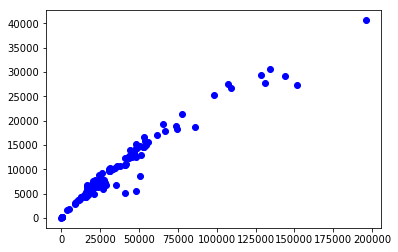

```python
import matplotlib.pyplot as plt
plt.plot(stats.length, stats.unique, "bo")
plt.show()
```

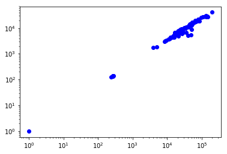

```python
plt.loglog(stats.length, stats.unique, "bo")
plt.show()
```

```python
stats[stats.language == 'English']
```

|  | language | author | title | length | unique |
| --- | --- | --- | --- | --- | --- |
| 1 | English | Abrahamlincoln | Bancroft_Copy | 270 | 138 |
| 2 | English | Abrahamlincoln | Bliss_Copy | 276 | 139 |
| 3 | English | Abrahamlincoln | DataCamp | 1 | 1 |
| 4 | English | Abrahamlincoln | Everett_Copy | 268 | 139 |
| 5 | English | Abrahamlincoln | Hay_Copy | 264 | 136 |
| 6 | English | Abrahamlincoln | Nicolay_Copy | 235 | 127 |
| 7 | English | Shakespeare | A Midsummer Night's Dream | 16103 | 4345 |
| 8 | English | Shakespeare | Hamlet | 28551 | 6776 |
| 9 | English | Shakespeare | Macbeth | 16874 | 4780 |
| 10 | English | Shakespeare | Othello | 26590 | 5898 |
| 11 | English | Shakespeare | Richard III | 48315 | 5449 |
| 12 | English | Shakespeare | Romeo and Juliet | 40776 | 5118 |
| 13 | English | Shakespeare | The Merchant of Venice | 20949 | 4978 |

```python
stats[stats.language == 'French']
```

|  | language | author | title | length | unique |
| --- | --- | --- | --- | --- | --- |
| 14 | French | Chevalier | L'enfer et le paradis de l'autre monde | 40827 | 10831 |
| 15 | French | Chevalier | L'åle de sable | 73801 | 18989 |
| 16 | French | Chevalier | La capitaine | 46306 | 13083 |
| 17 | French | Chevalier | La fille des indiens rouges | 66621 | 17875 |
| 18 | French | Chevalier | La fille du pirate | 52519 | 14649 |
| 19 | French | Chevalier | Le chasseur noir | 51341 | 12945 |
| 20 | French | Chevalier | Les derniers Iroquois | 55565 | 15583 |
| 21 | French | De maupassant | Boule de Suif | 35905 | 10725 |
| 22 | French | De maupassant | Claire de Lune | 25975 | 8076 |
| 23 | French | De maupassant | Contes de la Becasse | 34723 | 10210 |
| 24 | French | De maupassant | L'inutile beautÇ | 37840 | 10781 |
| 25 | French | De maupassant | La Main Gauche | 33481 | 9983 |
| 26 | French | De maupassant | La Maison Tellier | 43685 | 12305 |
| 27 | French | De maupassant | La petite roque | 40688 | 10890 |
| 28 | French | De maupassant | Le Horla | 41485 | 11091 |
| 29 | French | De maupassant | Œuvres complètes de Guy de Maupassant | 54772 | 15028 |
| 30 | French | Diderot | Ceci n'est pas un conte | 10938 | 3674 |
| 31 | French | Diderot | Entretien d'un päre avec ses enfants | 11125 | 3720 |
| 32 | French | Diderot | L'oiseau blanc | 21973 | 6337 |
| 33 | French | Diderot | Les deux amis de Bourbonne | 8510 | 2929 |
| 34 | French | Diderot | Regrets sur ma vieille robe de chambre | 4980 | 1876 |
| 35 | French | Sand | cora | 12370 | 4370 |
| 36 | French | Sand | Jacques le fataliste et son maåtre | 85756 | 18744 |
| 37 | French | Sand | L' Orco | 8748 | 3162 |
| 38 | French | Sand | La Coupe; Lupo Liverani; Le Toast; Garnier; Le... | 47831 | 12540 |
| 39 | French | Sand | La Marquise | 14716 | 4786 |
| 40 | French | Sand | Le Piccinino | 151405 | 27435 |
| 41 | French | Sand | Le poâme de Myrza | 12771 | 4348 |
| 42 | French | Sand | Mattea | 21089 | 6429 |
| 43 | French | Sand | Metella | 19600 | 5715 |
| 44 | French | Sand | Oeuvres illustrÇes de George Sand | 23210 | 7503 |
| 45 | French | Sand | Pauline | 27486 | 7901 |

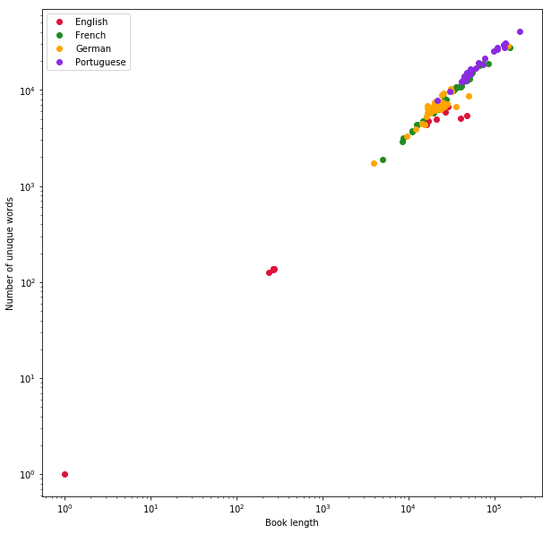

```python
plt.figure(figsize = (10,10))
subset = stats[stats.language == 'English']
plt.loglog(subset.length, subset.unique, "o", label = "English", color="crimson")

subset = stats[stats.language == 'French']
plt.loglog(subset.length, subset.unique, "o", label = "French", color="forestgreen")

subset = stats[stats.language == 'German']
plt.loglog(subset.length, subset.unique, "o", label = "German", color="orange")

subset = stats[stats.language == 'Portuguese']
plt.loglog(subset.length, subset.unique, "o", label = "Portuguese", color="blueviolet")
plt.legend()
plt.xlabel("Book length")
plt.ylabel("Number of unuque words")
plt.savefig("lang_plot.pdf")
plt.show()
```

stats is a Pandas dataframe, How can you access the column "length" in this dataframe?  
ANsWER: stats.length and stats["length"]

How can you select only the rows where the language is French?  
ANSWER: stats[stats.language == "French"]

### Exercise 1

In this case study, we will find and plot the distribution of word frequencies for each translation of Hamlet. Perhaps the distribution of word frequencies of Hamlet depends on the translation --- let's find out!

For these exercises, functions count_words_fast, read_book, and word_stats are already defined as in the Case 2 Videos (Videos 3.2.x).

Write a function word_count_distribution(text) that takes a book string and returns a dictionary with items corresponding to the count of times a collection of words appears in the translation, and values corresponding to the number of number of words that appear with that frequency.

First use count_words_fast(text) to create a dictionary called word_counts with unique words in the dictionary as keys and their frequency in the book as values.

Next, create and return a new dictionary count_distribution with unique values from word_counts as keys and their frequency as values. For example, 'you are what you eat' contains three words that occur once and one word that occurs twice, so word_count_distribution('you are what you eat') should return a dictionary {1:3, 2:1}.

'Romeo and Juliet' is preloaded as text. Call word_count_distribution(text), and save the result as distribution.

```python
from collections import Counter
import os
os.chdir('D:/Dev/Python/PythonForResearch/books/English/shakespeare')

with open('Romeo and Juliet.txt', "r") as f:
    seq = f.read()
    seq = seq.replace("\n", "")
    seq = seq.replace("\r", "")

def count_words_fast(text):
    """Count the number of times each word occurs in text (str). Return dictionary where keys are unique words
    and values are word counts. Skip punctuation. using the collection"""
    text = text.lower()
    skips = [".",",",":",";","'",'"']
    for ch in skips:
        text = text.replace(ch, "")

    word_counts = Counter(text.split(" "))
    return word_counts

def word_count_distribution(text):
    word_counts = count_words_fast(text)
    count_distribution = Counter(word_counts.values())
    return count_distribution

distribution = word_count_distribution(seq)
```

### Exercise 2

In this case study, we will find and plot the distribution of word frequencies for each translation of Hamlet. Perhaps the distribution of word frequencies of Hamlet depends on the translation --- let's find out!

For these exercises, functions count_words_fast, read_book, and word_stats are already defined as in the Case 2 Videos (Videos 3.2.x)

Create a function more_frequent(distribution) that takes a word frequency dictionary (like that made in Exercise 1) and outputs a dictionary with the same keys as those in distribution (the number of times a group of words appears in the text), and values corresponding to the fraction of words that occur with more frequency than that key.

Call more_frequent(distribution), and store as cumulative.

```python
import numpy as np
def more_frequent(distribution):
    counts  = list(distribution.keys())
    frequency_of_counts  = list(distribution.values())
    freq = np.cumsum(frequency_of_counts)
    more_frequency = 1 - freq/freq[-1]
    return dict(zip(counts, more_frequency))

cumulative  = more_frequent(distribution)
print(cumulative)
```

```
{1: 0.38882375928096913, 67: 0.38823759280969128, 23: 0.38608831574833924, 10: 0.37807737397420871, 527: 0.37788198515044935, 116: 0.3776865963266901, 777: 0.37749120750293086, 57: 0.37710042985541226, 126: 0.37690504103165301, 7: 0.36440015631105904, 367: 0.36420476748729969, 254: 0.364009378663540…
```

### Exercise 3

In this case study, we will find and plot the distribution of word frequencies for each translation of Hamlet. Perhaps the distribution of word frequencies of Hamlet depends on the translation --- let's find out!

For these exercises, functions count_words_fast, read_book, and word_stats are already defined as in the Case 2 Videos (Videos 3.2.x)

Edit the code used to read though each of the books in our library, and store the word frequency distribution for each translation of William Shakespeare's "Hamlet" as a Pandas dataframe hamlets with columns named "language" and "distribution". word_count_distribution is preloaded from Exercise 1. How many translations are there? Which languages are they translated into?

```python
import pandas as pd
hamlets = pd.DataFrame(columns=("language", "distribution"))  # add code here
book_dir = "Books"
title_num = 1
for language in book_titles:
    for author in book_titles[language]:
        for title in book_titles[language][author]:
            if title == "Hamlet":
                inputfile = data_filepath+"Books/"+language+"/"+author+"/"+title+".txt"
                text = read_book(inputfile)
                distribution = word_count_distribution(text)   # ADD code here
                hamlets.loc[title_num] = language, distribution
                title_num += 1
```

[output not shown]

### Exercise 4

In this case study, we will find and plot the distribution of word frequencies for each translation of Hamlet. Perhaps the distribution of word frequencies of Hamlet depends on the translation --- let's find out!

For these exercises, functions count_words_fast, read_book, and word_stats are already defined as in the Case 2 Videos (Videos 3.2.x)

Plot the word frequency distributions of each translations on a single log-log plot. Note that we have already done most of the work for you. Do the distributions of each translation differ?

[figure not shown]

```python
import matplotlib.pyplot as plt
colors = ["crimson", "forestgreen", "blueviolet"]
handles, hamlet_languages = [], []
for index in range(hamlets.shape[0]):
    language, distribution = hamlets.language[index+1], hamlets.distribution[index+1]
    dist = more_frequent(distribution)
    plot, = plt.loglog(sorted(list(dist.keys())),sorted(list(dist.values()),
        reverse = True), color = colors[index], linewidth = 2)
    handles.append(plot)
    hamlet_languages.append(language)
plt.title("Word Frequencies in Hamlet Translations")
xlim    = [0, 2e3]
xlabel  = "Frequency of Word $W$"
ylabel  = "Fraction of Words\nWith Greater Frequency than $W$"
plt.xlim(xlim); plt.xlabel(xlabel); plt.ylabel(ylabel)
plt.legend(handles, hamlet_languages, loc = "upper right", numpoints = 1)
# show your plot using `plt.show`!
plt.show()
```

## Introduction to kNN Classification

- k-Nearest Neighbors

Statistical learning refers to a collection of mathematical and computation tools to understand data.  
In what is often called supervised learning, the goal is to estimate or predict an output based on one or more inputs.

The inputs have many names, like predictors, independent variables, features, and variables being called common.

The output or outputs are often called response variables, or dependent variables.

If the response is quantitative-- say, a number that measures weight or height, we call these problems regression problems.

If the response is qualitative-- say, yes or no, or blue or green, we call these problems classification problems.

This case study deals with one specific approach to classification. The goal is to set up a classifier such that when it's presented with a new observation whose category is not known, it will attempt to assign that observation to a category, or a class, based on the observations for which it does know the true category.

This specific method is known as the k-Nearest Neighbors classifier, or kNN for short.  
Given a positive integer k, say 5, and a new data point, it first identifies those k points in the data that are nearest to the point and classifies the new data point as belonging to the most common class among those k neighbors.

### Introduction to kNN Classification: Question 1

How does the k-Nearest Neighbors classifier classify observations?  
ANsWEr: According to the most common class among the nearest k neighbors

### Finding the Distance between two points

finding the Euclidean distance

first data point (x<sub>1</sub>, y<sub>1</sub>)  
second data point (x<sub>2</sub>, y<sub>2</sub>)

|x<sub>2</sub> - x<sub>1</sub>|  
|y<sub>2</sub> - y<sub>1</sub>|  
d<sup>2</sup> = (x<sub>2</sub> - x<sub>1</sub>)<sup>2</sup> + (y<sub>2</sub> - y<sub>1</sub>)<sup>2</sup>  
d = √(x<sub>2</sub> - x<sub>1</sub>)<sup>2</sup> + (y<sub>2</sub> - y<sub>1</sub>)<sup>2</sup>

We'll be using numpy and use row vectors rather than column vectors

```python
import numpy as np
def distance(p1,p2):
    '''Find the distance between points p1 and p2.'''
    return np.sqrt(np.sum(np.power(p2-p1,2)))

p1 = np.array([1,1])
p2 = np.array([4,4])
distance(p1,p2)
```

```
4.2426406871192848
```

### Finding Distance: Question 1

How is the distance measure we use (as in Video 3.3.2) defined between points (a1, b1) and (a2, b2)?

ANSWER: √(a<sub>2</sub> - a<sub>1</sub>)<sup>2</sup> + (b<sub>2</sub> - b<sub>1</sub>)<sup>2</sup>)

### Majority Vote

- Most common vote
- compare two different methods if we had two 1s, three 2s and one 3, the majority vote would be 2

```python
def majority_vote(votes):
    '''xx'''
    vote_counts = {}
    for vote in votes:
        if vote in vote_counts:
            vote_counts[vote] += 1
        else:
            vote_counts[vote] = 1
    return vote_counts

votes = [1,2,3,1,2,3,1,2,3,3,3,3]
vote_counts = majority_vote(votes)
vote_counts
```

```
{1: 3, 2: 3, 3: 6}
```

```python
max(vote_counts)
```

```
3
```

```python
max(vote_counts.keys())
```

```
3
```

```python
max_counts = max(vote_counts.values())
```

```python
for vote, count in vote_counts.items():
    print(vote, count)
```

```
1 3
2 3
3 6
```

```python
winners = []
for vote, count in vote_counts.items():
    if count == max_counts:
        winners.append(vote)
winners
```

```
[3]
```

```python
import random
def majority_vote(votes):
    '''xxx'''
    vote_counts = {}
    for vote in votes:
        if vote in vote_counts:
            vote_counts[vote] += 1
        else:
            vote_counts[vote] = 1

    winners = []
    max_count = max(vote_counts.values())
    for vote, count in vote_counts.items():
        if count == max_count:
            winners.append(vote)
    return random.choice(winners)

votes = [1,2,3,1,2,3,1,2,3,3,3,3]
winner = majority_vote(votes)
winner
```

```
3
```

most commonly occurring element in a sequence is called mode in statistics

```python
import scipy.stats as ss
def majority_vote_short(voters):
    '''Return the most common element in votes'''
    mode, count = ss.mstats.mode(votes)
    return mode

votes = [1,2,3,1,2,3,1,2,3,3,3,3]
win = majority_vote_short(votes)
win
```

```
array([ 3.])
```

### Majority Vote: Question 1

What does the items method for dictionaries return? ANSWER: A dict_items object with elements consisting of tuples of key, value pairs

### Majority Vote: Question 2

What will random.choice() return for a list containing only one object? (Assume that the random module has already been imported.)  
ANSWER:This code returns the single element every time

### Finding Nearest Neighbors

- find the nearest neighbors
- use the nearest neighbors to Predict the class of an observations

The first is to loop over all points. For any given point, we want to compute the distance between point P, a point, we're hoping to classify, and every other point. Once we're done with that, we'd like to sort distances and return those k points that are nearest to point p.

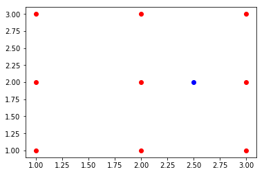

```python
points = np.array([[1,1],[1,2],[1,3],[2,1],[2,2],[2,3],[3,1],[3,2],[3,3]])
distances = np.zeros(points.shape[0])
p = np.array([2.5,2])
for i in range(len(distances)):
    distances[i] = distance(p, points[i])



import matplotlib.pyplot as plt
plt.plot(points[:,0], points[:,1], "ro")
plt.plot(p[0], p[1], "bo")
#plt.axis([0.5,3.5,0.5,3.5])
plt.show()
```

```python
distances
```

```
array([ 1.80277564,  1.5       ,  1.80277564,  1.11803399,  0.5       ,
        1.11803399,  1.11803399,  0.5       ,  1.11803399])
```

```python
points[4]
```

```
array([2, 2])
```

```python
distances[4]
```

```
0.5
```

```python
ind = np.argsort(distances)
ind
```

```
array([4, 7, 3, 5, 6, 8, 1, 0, 2], dtype=int64)
```

```python
distances[ind]
```

```
array([ 0.5       ,  0.5       ,  1.11803399,  1.11803399,  1.11803399,
        1.11803399,  1.5       ,  1.80277564,  1.80277564])
```

```python
distances[ind[0:2]]
```

```
array([ 0.5,  0.5])
```

```python
def find_nearest_neighbors(p,points, k=5):
    '''Find the k nearest neighbors of points p and return their indices.'''
    distances = np.zeros(points.shape[0])
    for i in range(len(distances)):
        distances[i] = distance(p,points[i])
    ind = np.argsort(distances)
    return ind[:k]

ind = find_nearest_neighbors(p, points, 2); print(points[ind])
```

```
[[2 2]
 [3 2]]
```

```python
def knn_predict(p, points, outcomes, k=5):
    # find k nearest neighbors
    ind = find_nearest_neighbors(p, points, k)
    return majority_vote(outcomes[ind])
    # predict the class of p based on majority vote
```

```python
outcomes = np.array([0,0,0,0,1,1,1,1,1])
len(outcomes)
```

```
9
```

```python
knn_predict(np.array([2.5,2.7]), points, outcomes, k=2)
```

```
1
```

```python
knn_predict(np.array([1.,2.7]), points, outcomes, k=2)
```

```
0
```

### Finding Nearest Neighbors: Question 1

For an np.array of dimension 2, what does the shape method return?  
ANSWER: A tuple containing the number of rows and columns

### Finding Nearest Neighbors: Question 2

What does np.argsort do?  
ANSWER: It sorts an array according to a single argument and returns the sorted indices.

### Generating Synthetic Data

We're going to write a function that generates two end data points, where the first end points are from class 0, and the second end points are from class 1.  
These data are known as synthetic data because we will be generating these data with the help of the computer.  
In this case, we'll generate predictors from two bivariate normal distributions, where the first distribution gives rise  
to observations belonging to class 0, and the second gives rise to observations belonging to class 1.

The word, bivariate, just means 2 variables, like x and y.  
If it were generating say, just the x variables, then we'd be dealing with univariate data.

To generate the synthetic data, we'll be using this ipstats module. First, we specify the mean and standard deviation for observations coming from class 1

```python
import scipy.stats as ss
ss.norm(0,1).rvs((5,2))  # generate 5 rows and 2 columns of observation normal distribution
```

```
array([[-0.49014416,  0.82340516],
       [ 1.20785883, -1.5716544 ],
       [-1.43699667, -0.14406878],
       [ 0.03364848,  0.28733344],
       [ 0.67316789, -1.31903148]])
```

```python
ss.norm(1,1).rvs((5,2))  # mean is 1
```

```
array([[ 2.28305719, -0.32731779],
       [-1.42176648, -1.07304597],
       [ 0.29479326,  1.08654371],
       [ 0.65705257,  0.58734277],
       [ 1.68065147, -0.69068118]])
```

```python
import numpy as np
np.concatenate((ss.norm(0,1).rvs((5,2)), ss.norm(1,1).rvs((5,2))), axis=0)  #concatenate along rows
```

```
array([[-0.87806901, -1.34380214],
       [-1.34117489, -0.09518377],
       [-1.67464263,  0.41958623],
       [ 0.28053425,  1.49806858],
       [-0.26079503, -0.41950227],
       [ 3.04882487,  1.68310228],
       [ 1.57687108, -0.14460874],
       [ 1.78612341,  0.81676888],
       [ 0.434537  ,  1.61984909],
       [ 0.24915819,  0.63483072]])
```

To turn, this into a function, we want to be able to specify the number of rows in out synthetic data set

```python
n=5   # rows 5 changed to n
np.concatenate((ss.norm(0,1).rvs((n,2)), ss.norm(1,1).rvs((n,2))), axis=0)  # rows 5 changed to n
```

```
array([[-1.06395953, -1.5944395 ],
       [-0.35349449,  0.44575758],
       [-1.32910931, -0.89579308],
       [-0.28427491, -0.3080023 ],
       [-0.31708398,  1.17976471],
       [ 1.85302092, -1.22821933],
       [ 1.99760463, -0.17943574],
       [-0.2321586 ,  1.58371337],
       [ 0.78076381,  0.18746609],
       [-0.13602511,  1.86035195]])
```

We also need to generate the outcomes, the first n observations have outcome equal to 0, which is the class label  
The second group of observations have class label or outcome equal to 1. Let's generate the outcome vector.

```python
n = 5
outcomes = np.concatenate((np.repeat(0,n), np.repeat(1,n)) )
```

```python
import os
os.chdir('D:/Dev/Python/PythonForResearch/classification')
import scipy.stats as ss
import numpy as np
import matplotlib.pyplot as plt
def generate_synth_data(n=50):
    '''Create two sets of points from bivariate normal distributions'''
    points = np.concatenate((ss.norm(0,1).rvs((n,2)), ss.norm(1,1).rvs((n,2))), axis=0)
    outcomes = np.concatenate((np.repeat(0,n), np.repeat(1,n)) )
    return (points, outcomes)
```

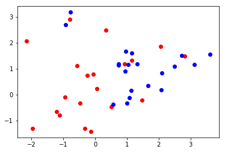

```python
n = 20

(points, outcomes) = generate_synth_data(n)

plt.figure()
plt.plot(points[:n,0], points[:n,1], "ro")
plt.plot(points[n:,0], points[n:,1], "bo")
plt.savefig("bivardata.pdf")
plt.show()
```

### Generating Synthetic Data: Question 1

What does np.concatenate do?  
Takes in a tuple of np.arrays and joins them lengthwise along the specified axis

### Generating Synthetic Data: Question 2

Do you expect the k-Nearest Neighbors to categorize new values in the synthetic data perfectly?  
ANSWER: No, because the data contain some observations with a majority of neighbors in another category

### Making a Prediction Grid

- how to make a prediction grid
- how to use enumerate
- how to use NumPy meshgrid

Our next task is to plot a prediction grid. This means that once we've observed our data, we can examine some part of the predictor space and compute the class prediction for each point in the grid using the knn classifier.

So instead of finding out how our classifier might classify a given point, we can ask how it classifies all points that belong to a rectangular region of the predictor space.

```python
def make_prediction_grid(predictor, outcomes, limits, h, k):    # limits will consists of 4 elements tuple
    """Classify each point on the prediciton grid. """
    (x_min, x_max, y_min, y_max) = limits
    xs = np.arange(x_min, x_max, h)   # x values of our grid, xmin to xmax and increment of h
    ys = np.arange(y_min, y_max, h)   # y values of our grid
    xx, yy = np.meshgrid(xs, ys)      # takes xy, ys and generate 2 dimensional arrays

    # next we need to generate our classifiers prediction corresponding to every point of the meshgrid
    prediction_grid = np.zeros(xx.shape, dtype = int)   # first fill with zeros and it is the same size as xx or yy
                                                        # dtype is int as the class label is either 0 or 1
    for i, x in enumerate(xs):
        for j, y in enumerate(ys):
            p = np.array([x,y])
            prediction_grid[j,i] = knn_predict(p, predictor, outcomes, k)
    return (xx, yy, prediction_grid)
```

prediction_grid[j,i] = knn_predict(p, predictor, outcomes, k)  
Note that we're doing the assignment j, i, not the other way around. This is because j corresponds to y values, and when we specify an index using square brackets, the first value, the first argument, corresponds to the role of the array. That's why we want to make sure that we will assign the y values the rows of the array and the x values the columns of array.

Let's look at the meshgrid in a little bit more detail. Meshgrid takes in two or more coordinate vectors, say one vector containing the x values of interest and the other containing the y values of interest. It returns matrices, the first containing the x values for each grid point and the second containing the y values for each grid point.

[figure not shown]

Enumerate is useful when dealing with sequences and when we'd like to have access simulataneously to two things-- different elements in the sequence as well as their index values.

```python
seasons = ["spring", "summer", "fall", "winter"]
list(enumerate(seasons))
```

```
[(0, 'spring'), (1, 'summer'), (2, 'fall'), (3, 'winter')]
```

```python
for ind, season in enumerate(seasons):
    print(ind, season)
```

```
0 spring
1 summer
2 fall
3 winter
```

### Making a Prediction Grid: Question 1

What does np.arange do?  
ANSWER: Creates regularly spaced values between the first and second argument, with spacing given in the third argument

### Making a Prediction Grid: Question 2

What does enumerate do?  
ANSWER: Takes an iterable and returns a new iterable with tuples as elements, where the first index of each tuple is the index of the tuple in the iterable

### Plotting the Prediction Grid

For us to be able to plot the prediction grid, we need one more function. This function is called **plot prediction grid**,and in this case we provide this to you on the course site. We can now try out different values for k. If you use a small value you'll see that the boundary between the colors, the so-called decision boundary, is more smooth the larger the value of k. This means that k controls the smoothness of the fit.

Let's first generate some synthetic data.

```python
(predictors, outcomes) = generate_synth_data()
```

```python
predictors.shape
```

```
(100, 2)
```

```python
outcomes.shape
```

```
(100,)
```

```python
import os
os.chdir('D:/Dev/Python/PythonForResearch/classification')
```

```python
def plot_prediction_grid (xx, yy, prediction_grid, filename):
    """ Plot KNN predictions for every point on the grid."""
    from matplotlib.colors import ListedColormap
    background_colormap = ListedColormap (["hotpink","lightskyblue", "yellowgreen"])
    observation_colormap = ListedColormap (["red","blue","green"])
    plt.figure(figsize =(10,10))
    plt.pcolormesh(xx, yy, prediction_grid, cmap = background_colormap, alpha = 0.5)
    plt.scatter(predictors[:,0], predictors [:,1], c = outcomes, cmap = observation_colormap, s = 50)
    plt.xlabel('Variable 1'); plt.ylabel('Variable 2')
    plt.xticks(()); plt.yticks(())
    plt.xlim (np.min(xx), np.max(xx))
    plt.ylim (np.min(yy), np.max(yy))
    plt.savefig(filename)
    plt.show()
```

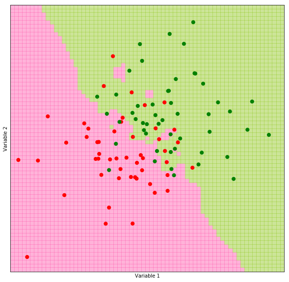

```python
k=5; filename="knn_synth_5.pdf"; limits = (-3,4,-3,4); h =0.1
(xx, yy, prediction_grid) = make_prediction_grid(predictors, outcomes, limits, h, k)
plot_prediction_grid(xx,yy, prediction_grid, filename)
```

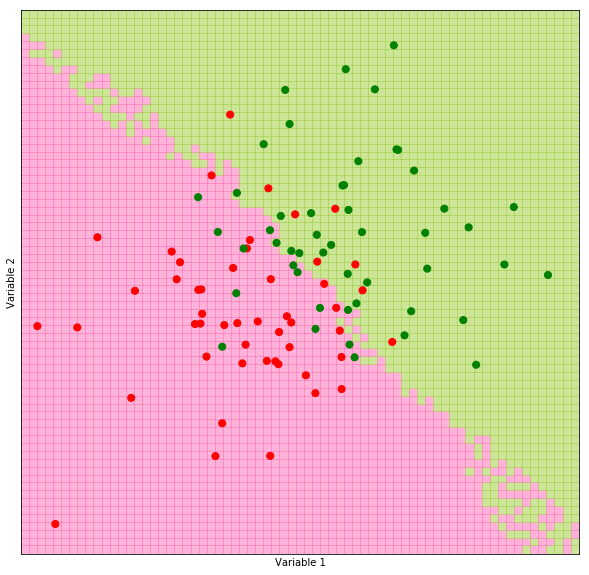

```python
k=50; filename="knn_synth_50.pdf"; limits = (-3,4,-3,4); h =0.1
(xx, yy, prediction_grid) = make_prediction_grid(predictors, outcomes, limits, h, k)
plot_prediction_grid(xx,yy, prediction_grid, filename)
```

Looking at the plot here for k equals 50, we can see that the decision boundary is pretty smooth. In contrast, if you look at the plot on the right, where k is equal to 5, you'll see that the shape of the decision boundary is more complicated. It seems that you might be able to find a value of k that maximizes the accuracy of the predictions. But that's somewhat short sighted. This is because what you really care about is not how well your method performs on the training data set, the data set we've used so far. But rather how well it performs on a future dataset you haven't yet seen. It turns out that using a value for k that's too large or too small is not optimal. A phenomenon that is known as the bias-variance tradeoff. This suggests that some intermediate values of k might be best. We will not talk more about it here, but for this application, using k equal to 5 is a reasonable choice.

### Applying the kNN Method

Iris dataset, 150 different iris flowers, 50 from each of 3 different species.  
Sepal length, sepal width, petal length, petal width

```python
from sklearn import datasets
iris = datasets.load_iris()
```

```python
# iris.data  # will list 150 rows or observations
iris.target
```

```
array([0, 0, 0, 0, 0, 0, 0, 0, 0, 0, 0, 0, 0, 0, 0, 0, 0, 0, 0, 0, 0, 0, 0,
       0, 0, 0, 0, 0, 0, 0, 0, 0, 0, 0, 0, 0, 0, 0, 0, 0, 0, 0, 0, 0, 0, 0,
       0, 0, 0, 0, 1, 1, 1, 1, 1, 1, 1, 1, 1, 1, 1, 1, 1, 1, 1, 1, 1, 1, 1,
       1, 1, 1, 1, 1, 1, 1, 1, 1, 1, 1, 1, 1, 1, 1, 1, 1, 1, 1, 1, 1, 1, 1,
       1, 1, 1, 1, 1, 1, 1, 1, 2, 2, 2, 2, 2, 2, 2, 2, 2, 2, 2, 2, 2, 2, 2,
       2, 2, 2, 2, 2, 2, 2, 2, 2, 2, 2, 2, 2, 2, 2, 2, 2, 2, 2, 2, 2, 2, 2,
       2, 2, 2, 2, 2, 2, 2, 2, 2, 2, 2, 2])
```

we have 4 different covariates which is why we have four columns. for simplicity, we'll just look at the first two covariates or predictors.

all rows but only column 0 and 1

```python
pred = iris.data[:,0:2]
```

We'll then build an outcomes vector, which is iris.target

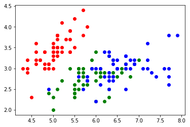

```python
plt.clf()      # clear all figures
outc = iris.target
plt.plot(pred[outc==0][:,0], pred[outc==0][:,1], "ro")
plt.plot(pred[outc==1][:,0], pred[outc==1][:,1], "go")
plt.plot(pred[outc==2][:,0], pred[outc==2][:,1], "bo")
plt.show()
```

```python
def make_pred_grid(predictor, outcomes, limits, h, k):    # limits will consists of 4 elements tuple
    """Classify each point on the prediciton grid. """
    (x_min, x_max, y_min, y_max) = limits
    xs = np.arange(x_min, x_max, h)   # x values of our grid, xmin to xmax and increment of h
    ys = np.arange(y_min, y_max, h)   # y values of our grid
    xx, yy = np.meshgrid(xs, ys)      # takes xy, ys and generate 2 dimensional arrays

    # next we need to generate our classifiers prediction corresponding to every point of the meshgrid
    prediction_grid = np.zeros(xx.shape, dtype = int)   # first fill with zeros and it is the same size as xx or yy
                                                        # dtype is int as the class label is either 0 or 1
    for i, x in enumerate(xs):
        for j, y in enumerate(ys):
            p = np.array([x,y])
            prediction_grid[j,i] = knn_predict(p, predictor, outcomes, k)
    return (xx, yy, prediction_grid)
```

```python
def plot_pred_grid (xx, yy, prediction_grid, filename):
    """ Plot KNN predictions for every point on the grid."""
    from matplotlib.colors import ListedColormap
    background_colormap = ListedColormap (["hotpink","lightskyblue", "yellowgreen"])
    observation_colormap = ListedColormap (["red","blue","green"])
    plt.figure(figsize =(10,10))
    plt.pcolormesh(xx, yy, prediction_grid, cmap = background_colormap, alpha = 0.5)
    plt.scatter(predictors[:,0], predictors [:,1], c = outcomes, cmap = observation_colormap, s = 50)
    plt.xlabel('Variable 1'); plt.ylabel('Variable 2')
    plt.xticks(()); plt.yticks(())
    plt.xlim (np.min(xx), np.max(xx))
    plt.ylim (np.min(yy), np.max(yy))
    plt.savefig(filename)
    plt.show()
```

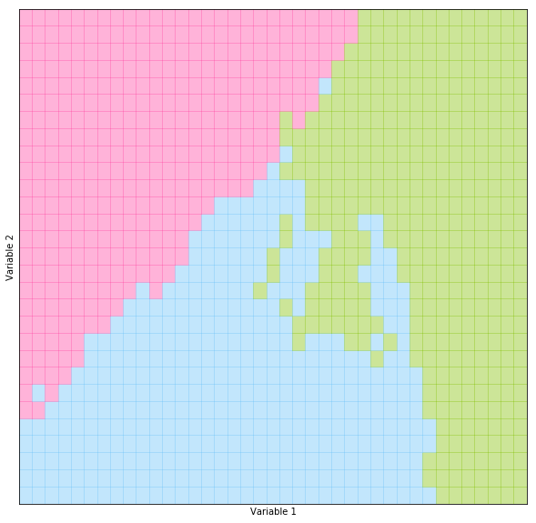

```python
k=5; filename="iris_grid.pdf"; limits = (4,8,1.5,4.5); h=0.1
(xx,yy, pred_grid) = make_pred_grid(pred, outc, limits, h, k)
plot_pred_grid(xx, yy, pred_grid, filename)
```

```python
from sklearn.neighbors import KNeighborsClassifier
knn= KNeighborsClassifier(n_neighbors = 5)
knn.fit(pred, outc)
sk_predicitons = knn.predict(pred)
```

```python
sk_predicitons.shape
```

```
(150,)
```

```python
my_predictions = np.array([knn_predict(p, pred, outc, 5) for p in pred])
my_predictions.shape
```

```
(150,)
```

```python
(sk_predicitons == my_predictions)
```

```
array([ True,  True,  True,  True,  True,  True,  True,  True,  True,
        True,  True,  True,  True,  True,  True,  True,  True,  True,
        True,  True,  True,  True,  True,  True,  True,  True,  True,
        True,  True,  True,  True,  True,  True,  True,  True,  True,
        True,  True,  True,  True,  True,  True,  True,  True,  True,
        True,  True,  True,  True,  True,  True,  True,  True,  True,
        True,  True,  True,  True,  True,  True,  True, False,  True,
        True,  True,  True,  True,  True,  True,  True,  True,  True,
        True,  True,  True,  True,  True, False,  True,  True,  True,
        True,  True,  True,  True, False,  True,  True,  True,  True,
        True,  True,  True,  True,  True,  True,  True,  True,  True,
        True,  True,  True,  True,  True,  True,  True,  True,  True,
       False,  True,  True,  True,  True,  True,  True,  True,  True,
        True,  True,  True,  True,  True,  True,  True,  True,  True,
        True,  True,  True,  True,  True,  True,  True,  True,  True,
        True,  True,  True,  True,  True,  True,  True,  True,  True,
        True, False,  True,  True,  True, False], dtype=bool)
```

```python
np.mean(sk_predicitons == my_predictions)
```

```
0.95999999999999996
```

```python
print(100 * np.mean(sk_predicitons == my_predictions))
```

```
96.0
```

```python
print(100 * np.mean(sk_predicitons == outc))
print(100 * np.mean(my_predictions == outc))
```

```
83.3333333333
84.6666666667
```

### Exercise 1

In this case study, we will analyze a dataset consisting of an assortment of wines classified as "high quality" and "low quality" and will use the k-Nearest Neighbors classifier to determine whether or not other information about the wine helps us correctly predict whether a new wine will be of high quality.

- Read in the data as a pandas dataframe using pd.read_csv. The data can be found at https://s3.amazonaws.com/demo-datasets/wine.csv.

```python
import pandas as pd
data = pd.read_csv("https://s3.amazonaws.com/demo-datasets/wine.csv")
```

### Exercise 2

In this case study, we will analyze a dataset consisting of an assortment of wines classified as "high quality" and "low quality" and will use the k-Nearest Neighbors classifier to determine whether or not other information about the wine helps us correctly predict whether a new wine will be of high quality.

- The dataset remains stored as data. Two columns in data are is_red and color, which are redundant. Drop color from the dataset, and save the new dataset as numeric_data.

```python
numeric_data = data.drop('color', axis=1)
```

### Exercise 3

In this case study, we will analyze a dataset consisting of an assortment of wines classified as "high quality" and "low quality" and will use the k-Nearest Neighbors classifier to determine whether or not other information about the wine helps us correctly predict whether a new wine will be of high quality.

To ensure that each variable contributes equally to the kNN classifier, we need to standardize the data. First, from each variable in numeric_data, subtract its mean. Second, for each variable in numeric_data, divide by its standard deviation. Store your standardized result as numeric_data.

Principal component analysis is a way to take a linear snapshot of the data from several different angles, with each snapshot ordered by how well it aligns with variation in the data. The sklearn.decomposition module contains the PCA class, which determines the most informative principal components of the data (a matrix with columns corresponding to the principal components). Use pca.fit(numeric_data).transform(numeric_data) to extract the first two principal components from the data. Store this as principal_components.

```python
numeric_data = (numeric_data - np.mean(numeric_data, axis=0)) / np.std(numeric_data, axis=0)

import sklearn.decomposition
pca = sklearn.decomposition.PCA(n_components=2)
principal_components = pca.fit(numeric_data).transform(numeric_data)
```

### Exercise 4

In this case study, we will analyze a dataset consisting of an assortment of wines classified as "high quality" and "low quality" and will use the k-Nearest Neighbors classifier to determine whether or not other information about the wine helps us correctly predict whether a new wine will be of high quality.

- The first two principal components can be accessed using principal_components[:,0] and principal_components[:,1]. Store these as x and y respectively, and plot the first two principal components. The high and low quality wines will be colored using red and blue. How well are the two groups of wines separated by the first two principal components?

[output not shown]

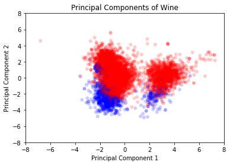

```python
import matplotlib.pyplot as plt
from matplotlib.colors import ListedColormap
from matplotlib.backends.backend_pdf import PdfPages
observation_colormap = ListedColormap(['red', 'blue'])
x = principal_components[:,0]
y = principal_components[:,1]

plt.title("Principal Components of Wine")
plt.scatter(x, y, alpha = 0.2,
    c = data['high_quality'], cmap = observation_colormap, edgecolors = 'none')
plt.xlim(-8, 8); plt.ylim(-8, 8)
plt.xlabel("Principal Component 1"); plt.ylabel("Principal Component 2")
plt.show()
```

### Exercise 5

In this case study, we will analyze a dataset consisting of an assortment of wines classified as "high quality" and "low quality" and will use the k-Nearest Neighbors classifier to determine whether or not other information about the wine helps us correctly predict whether a new wine will be of high quality.

- We are now ready to fit the wine data to our kNN classifier. Create a function accuracy(predictions, outcomes) that takes two lists of the same size as arguments and returns a single number, which is the percentage of elements that are equal for the two lists.
- Use accuracy to compare the percentage of similar elements in x = np.array([1,2,3]) and y = np.array([1,2,4]).

```python
def accuracy(predictions, outcomes):
    # Enter your code here!
    return 100 * np.mean(predictions == outcomes)

x = np.array([1,2,3])
y = np.array([1,2,4])

print(accuracy(x,y))
```

```
66.6666666667
```

### Exercise 6

In this case study, we will analyze a dataset consisting of an assortment of wines classified as "high quality" and "low quality" and will use the k-Nearest Neighbors classifier to determine whether or not other information about the wine helps us correctly predict whether a new wine will be of high quality.

- The dataset remains stored as data. Because most wines in the dataset are classified as low quality, one very simple classification rule is to predict that all wines are of low quality. Use the accuracy function (preloaded into memory as defined in Exercise 5) to calculate how many wines in the dataset are of low quality. Accomplish this by calling accuracy with 0 as the first argument, and data["high_quality"] as the second argument.

```python
wine = pd.read_csv('D:\\Dev\\Python\\DataCamp\\SupervisedLearningwithscikitlearn\\1 Classification\\datasets\\wine.csv')
```

```python
print(accuracy(0,wine["high_quality"]))
```

```
80.3447745113
```

### Exercise 7

In this case study, we will analyze a dataset consisting of an assortment of wines classified as "high quality" and "low quality" and will use the k-Nearest Neighbors classifier to determine whether or not other information about the wine helps us correctly predict whether a new wine will be of high quality.

- Use knn.predict(numeric_data) to predict which wines are high and low quality and store the result as library_predictions.
- Use accuracy to find the accuracy of your predictions, using library_predictions as the first argument and data["high_quality"] as the second argument.
- Print your answer. Is this prediction better than the simple classifier in Exercise 6?

```
from sklearn.neighbors import KNeighborsClassifier
knn = KNeighborsClassifier(n_neighbors = 5)
knn.fit(numeric_data, data['high_quality'])
# Enter your code here!
```

```python
from sklearn.neighbors import KNeighborsClassifier
knn = KNeighborsClassifier(n_neighbors = 5)
knn.fit(numeric_data, data['high_quality'])
# Enter your code here!
library_predictions = knn.predict(numeric_data)
print(accuracy(library_predictions, data["high_quality"]))
```

```
99.9692165615
```

### Exercise 8

In this case study, we will analyze a dataset consisting of an assortment of wines classified as "high quality" and "low quality" and will use the k-Nearest Neighbors classifier to determine whether or not other information about the wine helps us correctly predict whether a new wine will be of high quality.

Unlike the scikit-learn function, our homemade kNN classifier does not take any shortcuts in calculating which neighbors are closest to each observation, so it is likely too slow to carry out on the whole dataset. To circumvent this, fix the random generator using random.seed(123), and select 10 rows from the dataset using random.sample(range(n_rows), 10). Store this selection as selection.

```python
n_rows = data.shape[0]

# Enter your code here.
random.seed(123)
selection = random.sample(range(n_rows),10)
```

### Exercise 9

In this case study, we will analyze a dataset consisting of an assortment of wines classified as "high quality" and "low quality" and will use the k-Nearest Neighbors classifier to determine whether or not other information about the wine helps us correctly predict whether a new wine will be of high quality.

- The sample of 10 row indices are stored as selection from the previous exercise. For each predictor p in predictors[selection], use knn_predict(p, predictors[training_indices,:], outcomes, k=5) to predict the quality of each wine in the prediction set, and store these predictions as a np.array called my_predictions. Note that knn_predict is already defined as in the Case 3 videos.
- Using the accuracy function, compare these results to the selected rows from the high_quality variable in data using my_predictions as the first argument and data.high_quality[selection] as the second argument. Store these results as percentage.

[output not shown]

```python
predictors = np.array(numeric_data)
training_indices = [i for i in range(len(predictors)) if i not in selection]
outcomes = np.array(wine["high_quality"])

my_predictions = np.array([knn_predict(p, predictors, outcomes, 5) for p in predictors[selection]])
percentage = accuracy(my_predictions, wine.high_quality[selection])
print(percentage)
```

```
100.0
```